# 김동욱-U2018031_v1.0

```python
%run ML.libaryPackage-1.0.0.ipynb
```

```python
import numpy as np
import pandas as pd
import matplotlib.pyplot as plt
from matplotlib import font_manager, rc
import seaborn as sns
import warnings
from sklearn.metrics import roc_curve
from sklearn.preprocessing import Imputer
from sklearn.model_selection import cross_val_score, StratifiedShuffleSplit
from sklearn.metrics import accuracy_score
from sklearn.metrics import roc_auc_score
from sklearn.metrics import f1_score
from sklearn.tree import DecisionTreeClassifier
from sklearn.metrics import classification_report
from imblearn.under_sampling import *
from sklearn.decomposition import PCA
from imblearn.combine import SMOTETomek
from lightgbm import LGBMClassifier
from sklearn.preprocessing import PolynomialFeatures

warnings.filterwarnings('ignore')
%matplotlib inline
```

## data checking

```python
# train data checking
train_data = pd.read_csv('./data/train.csv', encoding='CP949')
train_data
```

|  | custid | gender | 총구매액 | 구매건수 | 평균구매가격 | 평균할부개월수 | 구매브랜드종류 | 내점일수 | 수입상품_구매비율 | 주말방문비율 | 가을_구매건수 | 겨울_구매건수 | 봄_구매건수 | 여름_구매건수 | 아침_구매건수 | 저녁_구매건수 | 점심_구매건수 | 주구매코너 |
| --- | --- | --- | --- | --- | --- | --- | --- | --- | --- | --- | --- | --- | --- | --- | --- | --- | --- | --- |
| 0 | 18 | 0 | 680100 | 15 | 45340 | 1.7 | 9 | 10 | 26.7 | 100.0 | NaN | 9.0 | 6.0 | NaN | NaN | 6.0 | 9.0 | 화장품 |
| 1 | 21 | 0 | 353450 | 9 | 39272 | 1.2 | 6 | 8 | 11.1 | 37.5 | NaN | 5.0 | 4.0 | NaN | 3.0 | NaN | 6.0 | 영캐주얼 |
| 2 | 23 | 0 | 5671400 | 36 | 157539 | 2.8 | 22 | 16 | 5.6 | 37.5 | 7.0 | 17.0 | 12.0 | NaN | 10.0 | 11.0 | 15.0 | 장신구 |
| 3 | 26 | 0 | 1964000 | 28 | 70143 | 1.4 | 15 | 14 | 39.3 | 28.6 | 5.0 | 8.0 | 15.0 | NaN | NaN | 18.0 | 10.0 | 화장품 |
| 4 | 35 | 0 | 885000 | 5 | 177000 | 6.0 | 5 | 2 | 0.0 | 100.0 | NaN | NaN | 5.0 | NaN | NaN | 5.0 | NaN | 피혁A |
| 5 | 50 | 0 | 3580200 | 36 | 99450 | 2.4 | 27 | 20 | 0.0 | 50.0 | 7.0 | 7.0 | 8.0 | 14.0 | 1.0 | 11.0 | 24.0 | 영캐주얼 |
| 6 | 69 | 0 | 816300 | 14 | 58307 | 1.7 | 10 | 10 | 7.1 | 40.0 | 4.0 | 4.0 | 6.0 | NaN | NaN | 3.0 | 11.0 | 유니캐주얼 |
| 7 | 82 | 0 | 752200 | 5 | 150440 | 2.6 | 5 | 3 | 60.0 | 100.0 | NaN | NaN | 5.0 | NaN | NaN | NaN | 5.0 | 화장품 |
| 8 | 92 | 0 | 1145400 | 13 | 88108 | 1.9 | 7 | 9 | 23.1 | 22.2 | 1.0 | NaN | 2.0 | 10.0 | 1.0 | 8.0 | 4.0 | 화장품 |
| 9 | 100 | 0 | 442160 | 16 | 27635 | 1.0 | 10 | 6 | 25.0 | 33.3 | NaN | 5.0 | 11.0 | NaN | NaN | 3.0 | 13.0 | 화장품 |
| 10 | 102 | 0 | 590000 | 5 | 118000 | 3.0 | 4 | 4 | 20.0 | 100.0 | 3.0 | 1.0 | NaN | 1.0 | NaN | NaN | 5.0 | 피혁A |
| 11 | 103 | 0 | 836600 | 15 | 55773 | 2.1 | 13 | 12 | 26.7 | 41.7 | 4.0 | 3.0 | 4.0 | 4.0 | NaN | 8.0 | 7.0 | 유니캐주얼 |
| 12 | 126 | 0 | 1892400 | 41 | 46156 | 1.6 | 26 | 28 | 19.5 | 39.3 | 10.0 | 7.0 | 3.0 | 21.0 | 4.0 | 14.0 | 23.0 | 화장품 |
| 13 | 148 | 0 | 2897110 | 24 | 120713 | 1.5 | 18 | 15 | 0.0 | 26.7 | 6.0 | 6.0 | 8.0 | 4.0 | 5.0 | 1.0 | 18.0 | 유니캐주얼 |
| 14 | 154 | 0 | 285000 | 4 | 71250 | 2.0 | 3 | 2 | 50.0 | 0.0 | NaN | NaN | 4.0 | NaN | NaN | 4.0 | NaN | 화장품 |
| 15 | 161 | 0 | 2215000 | 28 | 79107 | 1.9 | 21 | 15 | 0.0 | 40.0 | 2.0 | 6.0 | 8.0 | 12.0 | NaN | 12.0 | 16.0 | 섬유 |
| 16 | 174 | 0 | 433600 | 8 | 54200 | 2.6 | 5 | 4 | 0.0 | 50.0 | NaN | 5.0 | NaN | 3.0 | NaN | 5.0 | 3.0 | 영캐주얼 |
| 17 | 175 | 0 | 6466400 | 66 | 97976 | 2.0 | 38 | 33 | 10.6 | 57.6 | 17.0 | 26.0 | 16.0 | 7.0 | 7.0 | 11.0 | 48.0 | 화장품 |
| 18 | 186 | 0 | 2305740 | 32 | 72054 | 2.0 | 19 | 16 | 15.6 | 68.8 | 11.0 | 4.0 | 2.0 | 15.0 | NaN | 17.0 | 15.0 | 화장품 |
| 19 | 196 | 0 | 3581560 | 36 | 99488 | 1.7 | 21 | 23 | 41.7 | 43.5 | 9.0 | 26.0 | NaN | 1.0 | 6.0 | 22.0 | 8.0 | 니트단품 |
| 20 | 214 | 0 | 429400 | 10 | 42940 | 1.8 | 9 | 8 | 0.0 | 25.0 | 7.0 | 2.0 | NaN | 1.0 | NaN | 7.0 | 3.0 | 유니캐주얼 |
| 21 | 216 | 0 | 1906100 | 35 | 54460 | 1.0 | 26 | 18 | 5.7 | 16.7 | 16.0 | 6.0 | 10.0 | 3.0 | 7.0 | 9.0 | 19.0 | 영캐주얼 |
| 22 | 217 | 0 | 208900 | 4 | 52225 | 1.5 | 2 | 1 | 25.0 | 100.0 | NaN | NaN | 4.0 | NaN | NaN | NaN | 4.0 | 일반식품 |
| 23 | 220 | 0 | 870470 | 7 | 124353 | 2.9 | 7 | 6 | 0.0 | 50.0 | 1.0 | 2.0 | 3.0 | 1.0 | NaN | 2.0 | 5.0 | 영캐주얼 |
| 24 | 224 | 0 | 31000 | 1 | 31000 | 1.0 | 1 | 1 | 0.0 | 0.0 | NaN | 1.0 | NaN | NaN | NaN | 1.0 | NaN | 화장품 |
| 25 | 239 | 0 | 407480 | 8 | 50935 | 1.8 | 8 | 6 | 12.5 | 50.0 | 3.0 | NaN | 2.0 | 3.0 | NaN | 1.0 | 7.0 | 화장품 |
| 26 | 252 | 0 | 101000 | 1 | 101000 | 3.0 | 1 | 1 | 0.0 | 0.0 | NaN | NaN | 1.0 | NaN | 1.0 | NaN | NaN | 화장품 |
| 27 | 255 | 0 | 61000 | 2 | 30500 | 1.0 | 2 | 1 | 50.0 | 100.0 | NaN | 2.0 | NaN | NaN | NaN | 2.0 | NaN | 화장품 |
| 28 | 261 | 0 | 1639035 | 19 | 86265 | 2.1 | 9 | 9 | 36.8 | 11.1 | 5.0 | 10.0 | 4.0 | NaN | NaN | 5.0 | 14.0 | 일반식품 |
| 29 | 263 | 0 | 115000 | 2 | 57500 | 1.0 | 2 | 2 | 0.0 | 50.0 | NaN | NaN | NaN | 2.0 | NaN | 1.0 | 1.0 | 스포츠 |
| ... | ... | ... | ... | ... | ... | ... | ... | ... | ... | ... | ... | ... | ... | ... | ... | ... | ... | ... |
| 4970 | 49682 | 1 | 397400 | 5 | 79480 | 1.8 | 5 | 5 | 20.0 | 40.0 | 1.0 | 1.0 | 2.0 | 1.0 | 1.0 | 2.0 | 2.0 | 유아동복 |
| 4971 | 49691 | 0 | 1508477 | 42 | 35916 | 1.6 | 7 | 29 | 2.4 | 55.2 | 10.0 | 20.0 | 9.0 | 3.0 | 5.0 | 1.0 | 36.0 | 일반식품 |
| 4972 | 49709 | 0 | 2613046 | 24 | 108877 | 2.3 | 9 | 14 | 4.2 | 57.1 | 12.0 | NaN | 4.0 | 8.0 | 4.0 | 3.0 | 17.0 | 일반식품 |
| 4973 | 49723 | 1 | 144673 | 6 | 24112 | 1.3 | 2 | 3 | 16.7 | 33.3 | NaN | 2.0 | 2.0 | 2.0 | 2.0 | 2.0 | 2.0 | 일반식품 |
| 4974 | 49724 | 1 | 120000 | 1 | 120000 | 3.0 | 1 | 1 | 100.0 | 100.0 | NaN | NaN | 1.0 | NaN | NaN | NaN | 1.0 | 화장품 |
| 4975 | 49729 | 1 | 2601277 | 27 | 96344 | 1.7 | 17 | 16 | 7.4 | 31.2 | 2.0 | 14.0 | 5.0 | 6.0 | 3.0 | 2.0 | 22.0 | 유아동복 |
| 4976 | 49732 | 0 | 60023394 | 191 | 314259 | 5.1 | 23 | 78 | 18.8 | 24.4 | 46.0 | 42.0 | 27.0 | 76.0 | 47.0 | 19.0 | 125.0 | 디자이너부띠끄 |
| 4977 | 49733 | 0 | 352072 | 5 | 70414 | 1.0 | 5 | 3 | 0.0 | 33.3 | 3.0 | NaN | 2.0 | NaN | 1.0 | NaN | 4.0 | 일반식품 |
| 4978 | 49744 | 1 | 1646590 | 13 | 126661 | 1.0 | 8 | 9 | 0.0 | 22.2 | 1.0 | 3.0 | 6.0 | 3.0 | 1.0 | 1.0 | 11.0 | 니트단품 |
| 4979 | 49763 | 0 | 4576174 | 56 | 81717 | 2.0 | 45 | 33 | 33.9 | 24.2 | 16.0 | 7.0 | 17.0 | 16.0 | 15.0 | NaN | 41.0 | 화장품 |
| 4980 | 49766 | 1 | 961000 | 5 | 192200 | 2.8 | 4 | 3 | 20.0 | 66.7 | NaN | 4.0 | 1.0 | NaN | 1.0 | NaN | 4.0 | 화장품 |
| 4981 | 49788 | 0 | 560000 | 4 | 140000 | 2.5 | 4 | 2 | 25.0 | 50.0 | NaN | 3.0 | 1.0 | NaN | NaN | NaN | 4.0 | 화장품 |
| 4982 | 49820 | 1 | 165660 | 5 | 33132 | 1.0 | 3 | 4 | 20.0 | 0.0 | 2.0 | NaN | 1.0 | 2.0 | NaN | NaN | 5.0 | 일반식품 |
| 4983 | 49843 | 1 | 2357600 | 12 | 196467 | 2.3 | 9 | 9 | 33.3 | 0.0 | 4.0 | 3.0 | 3.0 | 2.0 | 6.0 | NaN | 6.0 | 화장품 |
| 4984 | 49846 | 1 | 19151837 | 88 | 217635 | 2.3 | 58 | 48 | 26.1 | 37.5 | 12.0 | 14.0 | 27.0 | 35.0 | 51.0 | 6.0 | 31.0 | 수입명품 |
| 4985 | 49847 | 0 | 461744 | 4 | 115436 | 2.5 | 3 | 3 | 50.0 | 33.3 | 2.0 | 1.0 | 1.0 | NaN | 2.0 | 2.0 | NaN | 화장품 |
| 4986 | 49848 | 0 | 342800 | 2 | 171400 | 3.5 | 2 | 2 | 50.0 | 0.0 | NaN | NaN | 1.0 | 1.0 | NaN | NaN | 2.0 | 유니캐주얼 |
| 4987 | 49857 | 1 | 8266055 | 38 | 217528 | 2.2 | 24 | 29 | 31.6 | 10.3 | 12.0 | 7.0 | 11.0 | 8.0 | 24.0 | NaN | 14.0 | 스포츠 |
| 4988 | 49862 | 1 | 2683160 | 57 | 47073 | 1.9 | 23 | 20 | 24.6 | 30.0 | 18.0 | 7.0 | 11.0 | 21.0 | 1.0 | 5.0 | 51.0 | 화장품 |
| 4989 | 49879 | 1 | 5001160 | 94 | 53204 | 1.9 | 18 | 65 | 2.1 | 29.2 | 18.0 | 15.0 | 41.0 | 20.0 | 52.0 | NaN | 42.0 | 일반식품 |
| 4990 | 49894 | 0 | 1387995 | 13 | 106769 | 3.2 | 5 | 12 | 7.7 | 25.0 | 4.0 | 6.0 | 3.0 | NaN | 7.0 | NaN | 6.0 | 일반식품 |
| 4991 | 49899 | 0 | 5731141 | 57 | 100546 | 2.2 | 29 | 33 | 12.3 | 33.3 | 1.0 | 27.0 | 17.0 | 12.0 | 1.0 | 1.0 | 55.0 | 유아동복 |
| 4992 | 49909 | 0 | 922000 | 6 | 153667 | 2.0 | 4 | 4 | 50.0 | 25.0 | 4.0 | NaN | NaN | 2.0 | NaN | 1.0 | 5.0 | 화장품 |
| 4993 | 49910 | 0 | 2363675 | 11 | 214880 | 2.8 | 8 | 9 | 36.4 | 44.4 | 3.0 | 4.0 | 1.0 | 3.0 | 4.0 | 2.0 | 5.0 | 일반식품 |
| 4994 | 49946 | 1 | 13525907 | 240 | 56358 | 1.4 | 45 | 126 | 6.2 | 27.8 | 57.0 | 66.0 | 49.0 | 68.0 | 52.0 | 35.0 | 153.0 | 일반식품 |
| 4995 | 49952 | 1 | 6666517 | 93 | 71683 | 1.8 | 27 | 39 | 10.8 | 43.6 | 13.0 | 33.0 | 14.0 | 33.0 | 8.0 | 41.0 | 44.0 | 일반식품 |
| 4996 | 49954 | 0 | 3112100 | 17 | 183065 | 3.6 | 10 | 13 | 29.4 | 38.5 | 4.0 | 6.0 | 6.0 | 1.0 | 3.0 | NaN | 14.0 | 디자이너부띠끄 |
| 4997 | 49957 | 1 | 5852482 | 37 | 158175 | 2.6 | 14 | 21 | 40.5 | 19.0 | 12.0 | 6.0 | 6.0 | 13.0 | 16.0 | NaN | 21.0 | 화장품 |
| 4998 | 49975 | 1 | 654498 | 13 | 50346 | 2.5 | 10 | 7 | 7.7 | 14.3 | 6.0 | 4.0 | 2.0 | 1.0 | NaN | 2.0 | 11.0 | 피혁A |
| 4999 | 49993 | 1 | 2554723 | 32 | 79835 | 1.7 | 9 | 26 | 21.9 | 34.6 | 6.0 | 5.0 | 10.0 | 11.0 | 8.0 | 5.0 | 19.0 | 일반식품 |

5000 rows × 18 columns

```python
# 예측할 new data 확인
test_data = pd.read_csv('./data/test.csv', encoding='CP949')
test_data
```

|  | custid | 총구매액 | 구매건수 | 평균구매가격 | 평균할부개월수 | 구매브랜드종류 | 내점일수 | 수입상품_구매비율 | 주말방문비율 | 가을_구매건수 | 겨울_구매건수 | 봄_구매건수 | 여름_구매건수 | 아침_구매건수 | 저녁_구매건수 | 점심_구매건수 | 주구매코너 |
| --- | --- | --- | --- | --- | --- | --- | --- | --- | --- | --- | --- | --- | --- | --- | --- | --- | --- |
| 0 | 100001 | 3439000 | 25 | 137560 | 2.2 | 19 | 16 | 12.0 | 31.2 | 5.0 | 4.0 | 7.0 | 9.0 | 13.0 | 1.0 | 11.0 | 장신구 |
| 1 | 100002 | 2073090 | 39 | 53156 | 1.3 | 18 | 29 | 0.0 | 20.7 | 13.0 | 8.0 | 10.0 | 8.0 | 4.0 | 10.0 | 25.0 | 유아동복 |
| 2 | 100003 | 1303800 | 22 | 59264 | 1.8 | 14 | 12 | 0.0 | 41.7 | 6.0 | 7.0 | 3.0 | 6.0 | 3.0 | 1.0 | 18.0 | 유아동복 |
| 3 | 100004 | 6696522 | 46 | 145577 | 1.7 | 31 | 22 | 37.0 | 50.0 | 5.0 | 15.0 | 9.0 | 17.0 | NaN | 4.0 | 42.0 | 수입명품 |
| 4 | 100005 | 1297640 | 26 | 49909 | 2.3 | 13 | 9 | 11.5 | 22.2 | 18.0 | NaN | 5.0 | 3.0 | NaN | NaN | 26.0 | 스포츠 |
| 5 | 100006 | 1071000 | 17 | 63000 | 1.4 | 11 | 12 | 11.8 | 25.0 | 3.0 | 12.0 | 2.0 | NaN | NaN | 11.0 | 6.0 | 섬유 |
| 6 | 100007 | 565400 | 8 | 70675 | 1.8 | 5 | 4 | 12.5 | 50.0 | 1.0 | NaN | NaN | 7.0 | 1.0 | NaN | 7.0 | 니트단품 |
| 7 | 100008 | 558610 | 9 | 62068 | 1.2 | 8 | 9 | 11.1 | 33.3 | 4.0 | 4.0 | 1.0 | NaN | NaN | 4.0 | 5.0 | 기타바이어 |
| 8 | 100009 | 3889520 | 44 | 88398 | 1.6 | 30 | 21 | 13.6 | 38.1 | 5.0 | 17.0 | 5.0 | 17.0 | 8.0 | 6.0 | 30.0 | 스포츠 |
| 9 | 100010 | 2318515 | 26 | 89174 | 1.3 | 10 | 16 | 19.2 | 43.8 | 9.0 | 3.0 | 10.0 | 4.0 | 3.0 | NaN | 23.0 | 일반식품 |
| 10 | 100011 | 5643401 | 82 | 68822 | 2.2 | 32 | 40 | 20.7 | 37.5 | 19.0 | 20.0 | 9.0 | 34.0 | 9.0 | 9.0 | 64.0 | 일반식품 |
| 11 | 100012 | 2264840 | 30 | 75495 | 1.5 | 27 | 17 | 3.3 | 29.4 | 2.0 | 3.0 | 9.0 | 16.0 | 15.0 | 1.0 | 14.0 | 유아동복 |
| 12 | 100013 | 487300 | 7 | 69614 | 2.4 | 5 | 4 | 0.0 | 75.0 | 4.0 | NaN | NaN | 3.0 | 3.0 | NaN | 4.0 | 정장셔츠 |
| 13 | 100014 | 682472 | 14 | 48748 | 1.0 | 7 | 10 | 7.1 | 30.0 | 4.0 | 4.0 | 4.0 | 2.0 | NaN | 12.0 | 2.0 | 일반식품 |
| 14 | 100015 | 3705689 | 15 | 247046 | 1.9 | 11 | 6 | 33.3 | 50.0 | 8.0 | 1.0 | NaN | 6.0 | 2.0 | 7.0 | 6.0 | 섬유 |
| 15 | 100016 | 6722660 | 32 | 210083 | 3.0 | 18 | 15 | 21.9 | 26.7 | 9.0 | 4.0 | 15.0 | 4.0 | 5.0 | 7.0 | 20.0 | 디자이너부띠끄 |
| 16 | 100017 | 6032500 | 75 | 80433 | 2.1 | 33 | 29 | 26.7 | 51.7 | 14.0 | 23.0 | 21.0 | 17.0 | 7.0 | 9.0 | 59.0 | 화장품 |
| 17 | 100018 | 2225600 | 16 | 139100 | 2.2 | 9 | 11 | 50.0 | 27.3 | 4.0 | NaN | 8.0 | 4.0 | 8.0 | NaN | 8.0 | 수입명품 |
| 18 | 100019 | 414000 | 4 | 103500 | 1.0 | 3 | 2 | 100.0 | 0.0 | NaN | 4.0 | NaN | NaN | NaN | NaN | 4.0 | 화장품 |
| 19 | 100020 | 15107942 | 47 | 321446 | 2.3 | 32 | 23 | 29.8 | 34.8 | 21.0 | 4.0 | 5.0 | 17.0 | 6.0 | 17.0 | 24.0 | 일반식품 |
| 20 | 100021 | 229000 | 3 | 76333 | 3.0 | 3 | 1 | 33.3 | 0.0 | NaN | 3.0 | NaN | NaN | NaN | NaN | 3.0 | 유아동복 |
| 21 | 100022 | 1981400 | 25 | 79256 | 1.5 | 17 | 14 | 8.0 | 64.3 | 6.0 | 11.0 | 3.0 | 5.0 | 1.0 | 1.0 | 23.0 | 영캐주얼 |
| 22 | 100023 | 191000 | 3 | 63667 | 1.7 | 3 | 1 | 66.7 | 0.0 | NaN | NaN | NaN | 3.0 | NaN | NaN | 3.0 | 화장품 |
| 23 | 100024 | 10525869 | 98 | 107407 | 2.4 | 42 | 34 | 16.3 | 32.4 | 26.0 | 31.0 | 16.0 | 25.0 | 22.0 | 19.0 | 57.0 | 유니캐주얼 |
| 24 | 100025 | 14726596 | 168 | 87658 | 2.0 | 84 | 53 | 13.1 | 45.3 | 47.0 | 25.0 | 44.0 | 52.0 | 93.0 | 13.0 | 62.0 | 유아동복 |
| 25 | 100026 | 3525382 | 29 | 121565 | 2.3 | 16 | 19 | 3.4 | 63.2 | 3.0 | 7.0 | 11.0 | 8.0 | 4.0 | 2.0 | 23.0 | 일반식품 |
| 26 | 100027 | 1227970 | 20 | 61398 | 2.2 | 14 | 11 | 45.0 | 18.2 | 7.0 | NaN | 2.0 | 11.0 | NaN | 4.0 | 16.0 | 수입명품 |
| 27 | 100028 | 380640 | 11 | 34604 | 1.4 | 11 | 8 | 9.1 | 50.0 | 5.0 | 1.0 | NaN | 5.0 | NaN | 5.0 | 6.0 | 화장품 |
| 28 | 100029 | 6399559 | 147 | 43534 | 1.7 | 47 | 55 | 0.0 | 32.7 | 46.0 | 34.0 | 35.0 | 32.0 | 28.0 | 25.0 | 94.0 | 스포츠 |
| 29 | 100030 | 4331510 | 35 | 123757 | 1.6 | 26 | 16 | 28.6 | 50.0 | 5.0 | 11.0 | 16.0 | 3.0 | NaN | 10.0 | 25.0 | 화장품 |
| ... | ... | ... | ... | ... | ... | ... | ... | ... | ... | ... | ... | ... | ... | ... | ... | ... | ... |
| 4970 | 104971 | 11345750 | 53 | 214071 | 1.6 | 35 | 18 | 30.2 | 44.4 | 22.0 | 14.0 | 15.0 | 2.0 | 1.0 | 8.0 | 44.0 | 정장셔츠 |
| 4971 | 104972 | 3240051 | 135 | 24000 | 1.3 | 35 | 45 | 8.1 | 24.4 | 48.0 | 50.0 | 17.0 | 20.0 | 8.0 | 51.0 | 76.0 | 일반식품 |
| 4972 | 104973 | 2693735 | 32 | 84179 | 1.8 | 9 | 20 | 18.8 | 45.0 | 11.0 | 9.0 | 5.0 | 7.0 | 1.0 | 9.0 | 22.0 | 일반식품 |
| 4973 | 104974 | 1055000 | 6 | 175833 | 2.7 | 6 | 4 | 50.0 | 75.0 | 2.0 | 2.0 | NaN | 2.0 | NaN | 4.0 | 2.0 | 화장품 |
| 4974 | 104975 | 274500 | 3 | 91500 | 1.7 | 3 | 3 | 33.3 | 66.7 | 2.0 | NaN | NaN | 1.0 | NaN | 3.0 | NaN | 유아동복 |
| 4975 | 104976 | 458200 | 2 | 229100 | 3.0 | 2 | 1 | 0.0 | 0.0 | NaN | NaN | NaN | 2.0 | NaN | NaN | 2.0 | 디자이너부띠끄 |
| 4976 | 104977 | 1851162 | 31 | 59715 | 1.3 | 18 | 18 | 16.1 | 22.2 | 5.0 | 12.0 | 4.0 | 10.0 | 7.0 | 4.0 | 20.0 | 일반식품 |
| 4977 | 104978 | 2680811 | 48 | 55850 | 1.6 | 28 | 26 | 8.3 | 7.7 | 20.0 | 5.0 | 9.0 | 14.0 | 33.0 | NaN | 15.0 | 일반식품 |
| 4978 | 104979 | 11661500 | 12 | 971792 | 2.2 | 6 | 9 | 83.3 | 44.4 | 1.0 | 4.0 | NaN | 7.0 | 3.0 | 1.0 | 8.0 | 수입명품 |
| 4979 | 104980 | 142000 | 2 | 71000 | 1.0 | 2 | 2 | 0.0 | 50.0 | 1.0 | NaN | NaN | 1.0 | 1.0 | NaN | 1.0 | 피혁A |
| 4980 | 104981 | 23884758 | 62 | 385238 | 2.2 | 45 | 24 | 16.1 | 37.5 | 16.0 | 9.0 | 15.0 | 22.0 | 12.0 | 13.0 | 37.0 | 스포츠 |
| 4981 | 104982 | 113000 | 1 | 113000 | 3.0 | 1 | 1 | 100.0 | 0.0 | NaN | NaN | 1.0 | NaN | NaN | NaN | 1.0 | 화장품 |
| 4982 | 104983 | 2148800 | 41 | 52410 | 1.2 | 27 | 21 | 19.5 | 19.0 | 12.0 | 4.0 | 13.0 | 12.0 | 6.0 | 4.0 | 31.0 | 화장품 |
| 4983 | 104984 | 3398860 | 29 | 117202 | 1.1 | 22 | 10 | 34.5 | 20.0 | NaN | 19.0 | 5.0 | 5.0 | NaN | 20.0 | 9.0 | 화장품 |
| 4984 | 104985 | 2149483 | 26 | 82672 | 2.1 | 18 | 21 | 15.4 | 57.1 | 7.0 | 5.0 | 3.0 | 11.0 | NaN | 6.0 | 20.0 | 화장품 |
| 4985 | 104986 | 259000 | 6 | 43167 | 1.7 | 5 | 5 | 16.7 | 0.0 | NaN | 1.0 | 4.0 | 1.0 | 1.0 | 2.0 | 3.0 | 화장품 |
| 4986 | 104987 | 1555600 | 10 | 155560 | 3.2 | 8 | 8 | 30.0 | 75.0 | 1.0 | 4.0 | 3.0 | 2.0 | 3.0 | 3.0 | 4.0 | 정장셔츠 |
| 4987 | 104988 | 237005 | 10 | 23700 | 1.6 | 7 | 5 | 20.0 | 0.0 | NaN | 2.0 | 1.0 | 7.0 | 4.0 | NaN | 6.0 | 도자기크리스탈 |
| 4988 | 104989 | 134270 | 4 | 33568 | 1.5 | 3 | 3 | 25.0 | 33.3 | NaN | 4.0 | NaN | NaN | 1.0 | NaN | 3.0 | 일반식품 |
| 4989 | 104990 | 124000 | 2 | 62000 | 1.0 | 2 | 2 | 50.0 | 50.0 | NaN | NaN | NaN | 2.0 | NaN | NaN | 2.0 | 화장품 |
| 4990 | 104991 | 826384 | 8 | 103298 | 3.4 | 4 | 6 | 0.0 | 16.7 | 1.0 | 1.0 | 2.0 | 4.0 | NaN | 1.0 | 7.0 | 화장품 |
| 4991 | 104992 | 3051050 | 40 | 76276 | 2.1 | 23 | 23 | 12.5 | 17.4 | 5.0 | 14.0 | 18.0 | 3.0 | 2.0 | 11.0 | 27.0 | 화장품 |
| 4992 | 104993 | 8446156 | 82 | 103002 | 2.1 | 44 | 48 | 1.2 | 18.8 | 21.0 | 24.0 | 17.0 | 20.0 | 12.0 | 24.0 | 46.0 | 유아동복 |
| 4993 | 104994 | 3679946 | 43 | 85580 | 2.3 | 27 | 24 | 2.3 | 29.2 | 8.0 | 13.0 | 6.0 | 16.0 | 8.0 | 8.0 | 27.0 | 유니캐주얼 |
| 4994 | 104995 | 1745665 | 21 | 83127 | 1.7 | 16 | 7 | 9.5 | 71.4 | 2.0 | NaN | 2.0 | 17.0 | 2.0 | 1.0 | 18.0 | 영캐주얼 |
| 4995 | 104996 | 670690 | 5 | 134138 | 1.4 | 5 | 4 | 0.0 | 75.0 | 1.0 | 2.0 | 2.0 | NaN | 1.0 | 1.0 | 3.0 | 일반식품 |
| 4996 | 104997 | 628700 | 13 | 48362 | 1.8 | 10 | 7 | 7.7 | 42.9 | NaN | 5.0 | 1.0 | 7.0 | NaN | 3.0 | 10.0 | 조리욕실 |
| 4997 | 104998 | 960923 | 12 | 80077 | 1.8 | 7 | 7 | 0.0 | 42.9 | 4.0 | 1.0 | 6.0 | 1.0 | NaN | NaN | 12.0 | 일반식품 |
| 4998 | 104999 | 786600 | 14 | 56186 | 1.7 | 12 | 9 | 14.3 | 55.6 | NaN | 7.0 | 4.0 | 3.0 | 2.0 | 4.0 | 8.0 | 화장품 |
| 4999 | 105000 | 2568073 | 76 | 33790 | 1.6 | 23 | 35 | 10.5 | 22.9 | 23.0 | 20.0 | 9.0 | 24.0 | 11.0 | 4.0 | 61.0 | 일반식품 |

5000 rows × 17 columns

```python
train_data.info()
test_data.info()
```

```
<class 'pandas.core.frame.DataFrame'>
RangeIndex: 5000 entries, 0 to 4999
Data columns (total 18 columns):
custid       5000 non-null int64
gender       5000 non-null int64
총구매액         5000 non-null int64
구매건수         5000 non-null int64
평균구매가격       5000 non-null int64
평균할부개월수      5000 non-null float64
구매브랜드종류      5000 non-null int64
내점일수         5000 non-null int64
수입상품_구매비율    5000 non-null float64
주말방문비율       5000 non-null float64
가을_구매건수      4055 non-null float64
겨울_구매건수      4103 non-null float64
봄_구매건수       4311 non-null float64
여름_구매건수      3978 non-null float64
아침_구매건수      3558 non-null float64
저녁_구매건수      4033 non-null float64
점심_구매건수      4855 non-null float64
주구매코너        5000 non-null object
dtypes: float64(10), int64(7), object(1)
memory usage: 703.2+ KB
<class 'pandas.core.frame.DataFrame'>
RangeIndex: 5000 entries, 0 to 4999
Data columns (total 17 columns):
custid       5000 non-null int64
총구매액         5000 non-null int64
구매건수         5000 non-null int64
평균구매가격       5000 non-null int64
평균할부개월수      5000 non-null float64
구매브랜드종류      5000 non-null int64
내점일수         5000 non-null int64
수입상품_구매비율    5000 non-null float64
주말방문비율       5000 non-null float64
가을_구매건수      4052 non-null float64
겨울_구매건수      4089 non-null float64
봄_구매건수       4319 non-null float64
여름_구매건수      4009 non-null float64
아침_구매건수      3608 non-null float64
저녁_구매건수      3975 non-null float64
점심_구매건수      4861 non-null float64
주구매코너        5000 non-null object
dtypes: float64(10), int64(6), object(1)
memory usage: 664.1+ KB
```

```python
display(train_data.shape)
display(test_data.shape)
```

```
(5000, 18)
```

```
(5000, 17)
```

## Missing Values 처리

```python
# Missing Values 확인
trainData = train_data.copy()
have_missing_value(trainData)
```

```
custid          0
gender          0
총구매액            0
구매건수            0
평균구매가격          0
평균할부개월수         0
구매브랜드종류         0
내점일수            0
수입상품_구매비율       0
주말방문비율          0
가을_구매건수       945
겨울_구매건수       897
봄_구매건수        689
여름_구매건수      1022
아침_구매건수      1442
저녁_구매건수       967
점심_구매건수       145
주구매코너           0
dtype: int64
```

```python
# Feature 정의
# 수치형 Features
cont = ['총구매액','구매건수','평균구매가격','평균할부개월수','내점일수',
       '수입상품_구매비율','주말방문비율', '봄_구매건수', '여름_구매건수',
       '가을_구매건수','겨울_구매건수','아침_구매건수', '점심_구매건수',
       '저녁_구매건수', '구매브랜드종류']
# 범주형 Features
cate = ['주구매코너']
# 비분석 Features : drop
delCols = ['custid']
# target Feature
dfy = 'gender'
```

```python
trainData
```

|  | custid | gender | 총구매액 | 구매건수 | 평균구매가격 | 평균할부개월수 | 구매브랜드종류 | 내점일수 | 수입상품_구매비율 | 주말방문비율 | 가을_구매건수 | 겨울_구매건수 | 봄_구매건수 | 여름_구매건수 | 아침_구매건수 | 저녁_구매건수 | 점심_구매건수 | 주구매코너 |
| --- | --- | --- | --- | --- | --- | --- | --- | --- | --- | --- | --- | --- | --- | --- | --- | --- | --- | --- |
| 0 | 18 | 0 | 680100 | 15 | 45340 | 1.7 | 9 | 10 | 26.7 | 100.0 | NaN | 9.0 | 6.0 | NaN | NaN | 6.0 | 9.0 | 화장품 |
| 1 | 21 | 0 | 353450 | 9 | 39272 | 1.2 | 6 | 8 | 11.1 | 37.5 | NaN | 5.0 | 4.0 | NaN | 3.0 | NaN | 6.0 | 영캐주얼 |
| 2 | 23 | 0 | 5671400 | 36 | 157539 | 2.8 | 22 | 16 | 5.6 | 37.5 | 7.0 | 17.0 | 12.0 | NaN | 10.0 | 11.0 | 15.0 | 장신구 |
| 3 | 26 | 0 | 1964000 | 28 | 70143 | 1.4 | 15 | 14 | 39.3 | 28.6 | 5.0 | 8.0 | 15.0 | NaN | NaN | 18.0 | 10.0 | 화장품 |
| 4 | 35 | 0 | 885000 | 5 | 177000 | 6.0 | 5 | 2 | 0.0 | 100.0 | NaN | NaN | 5.0 | NaN | NaN | 5.0 | NaN | 피혁A |
| 5 | 50 | 0 | 3580200 | 36 | 99450 | 2.4 | 27 | 20 | 0.0 | 50.0 | 7.0 | 7.0 | 8.0 | 14.0 | 1.0 | 11.0 | 24.0 | 영캐주얼 |
| 6 | 69 | 0 | 816300 | 14 | 58307 | 1.7 | 10 | 10 | 7.1 | 40.0 | 4.0 | 4.0 | 6.0 | NaN | NaN | 3.0 | 11.0 | 유니캐주얼 |
| 7 | 82 | 0 | 752200 | 5 | 150440 | 2.6 | 5 | 3 | 60.0 | 100.0 | NaN | NaN | 5.0 | NaN | NaN | NaN | 5.0 | 화장품 |
| 8 | 92 | 0 | 1145400 | 13 | 88108 | 1.9 | 7 | 9 | 23.1 | 22.2 | 1.0 | NaN | 2.0 | 10.0 | 1.0 | 8.0 | 4.0 | 화장품 |
| 9 | 100 | 0 | 442160 | 16 | 27635 | 1.0 | 10 | 6 | 25.0 | 33.3 | NaN | 5.0 | 11.0 | NaN | NaN | 3.0 | 13.0 | 화장품 |
| 10 | 102 | 0 | 590000 | 5 | 118000 | 3.0 | 4 | 4 | 20.0 | 100.0 | 3.0 | 1.0 | NaN | 1.0 | NaN | NaN | 5.0 | 피혁A |
| 11 | 103 | 0 | 836600 | 15 | 55773 | 2.1 | 13 | 12 | 26.7 | 41.7 | 4.0 | 3.0 | 4.0 | 4.0 | NaN | 8.0 | 7.0 | 유니캐주얼 |
| 12 | 126 | 0 | 1892400 | 41 | 46156 | 1.6 | 26 | 28 | 19.5 | 39.3 | 10.0 | 7.0 | 3.0 | 21.0 | 4.0 | 14.0 | 23.0 | 화장품 |
| 13 | 148 | 0 | 2897110 | 24 | 120713 | 1.5 | 18 | 15 | 0.0 | 26.7 | 6.0 | 6.0 | 8.0 | 4.0 | 5.0 | 1.0 | 18.0 | 유니캐주얼 |
| 14 | 154 | 0 | 285000 | 4 | 71250 | 2.0 | 3 | 2 | 50.0 | 0.0 | NaN | NaN | 4.0 | NaN | NaN | 4.0 | NaN | 화장품 |
| 15 | 161 | 0 | 2215000 | 28 | 79107 | 1.9 | 21 | 15 | 0.0 | 40.0 | 2.0 | 6.0 | 8.0 | 12.0 | NaN | 12.0 | 16.0 | 섬유 |
| 16 | 174 | 0 | 433600 | 8 | 54200 | 2.6 | 5 | 4 | 0.0 | 50.0 | NaN | 5.0 | NaN | 3.0 | NaN | 5.0 | 3.0 | 영캐주얼 |
| 17 | 175 | 0 | 6466400 | 66 | 97976 | 2.0 | 38 | 33 | 10.6 | 57.6 | 17.0 | 26.0 | 16.0 | 7.0 | 7.0 | 11.0 | 48.0 | 화장품 |
| 18 | 186 | 0 | 2305740 | 32 | 72054 | 2.0 | 19 | 16 | 15.6 | 68.8 | 11.0 | 4.0 | 2.0 | 15.0 | NaN | 17.0 | 15.0 | 화장품 |
| 19 | 196 | 0 | 3581560 | 36 | 99488 | 1.7 | 21 | 23 | 41.7 | 43.5 | 9.0 | 26.0 | NaN | 1.0 | 6.0 | 22.0 | 8.0 | 니트단품 |
| 20 | 214 | 0 | 429400 | 10 | 42940 | 1.8 | 9 | 8 | 0.0 | 25.0 | 7.0 | 2.0 | NaN | 1.0 | NaN | 7.0 | 3.0 | 유니캐주얼 |
| 21 | 216 | 0 | 1906100 | 35 | 54460 | 1.0 | 26 | 18 | 5.7 | 16.7 | 16.0 | 6.0 | 10.0 | 3.0 | 7.0 | 9.0 | 19.0 | 영캐주얼 |
| 22 | 217 | 0 | 208900 | 4 | 52225 | 1.5 | 2 | 1 | 25.0 | 100.0 | NaN | NaN | 4.0 | NaN | NaN | NaN | 4.0 | 일반식품 |
| 23 | 220 | 0 | 870470 | 7 | 124353 | 2.9 | 7 | 6 | 0.0 | 50.0 | 1.0 | 2.0 | 3.0 | 1.0 | NaN | 2.0 | 5.0 | 영캐주얼 |
| 24 | 224 | 0 | 31000 | 1 | 31000 | 1.0 | 1 | 1 | 0.0 | 0.0 | NaN | 1.0 | NaN | NaN | NaN | 1.0 | NaN | 화장품 |
| 25 | 239 | 0 | 407480 | 8 | 50935 | 1.8 | 8 | 6 | 12.5 | 50.0 | 3.0 | NaN | 2.0 | 3.0 | NaN | 1.0 | 7.0 | 화장품 |
| 26 | 252 | 0 | 101000 | 1 | 101000 | 3.0 | 1 | 1 | 0.0 | 0.0 | NaN | NaN | 1.0 | NaN | 1.0 | NaN | NaN | 화장품 |
| 27 | 255 | 0 | 61000 | 2 | 30500 | 1.0 | 2 | 1 | 50.0 | 100.0 | NaN | 2.0 | NaN | NaN | NaN | 2.0 | NaN | 화장품 |
| 28 | 261 | 0 | 1639035 | 19 | 86265 | 2.1 | 9 | 9 | 36.8 | 11.1 | 5.0 | 10.0 | 4.0 | NaN | NaN | 5.0 | 14.0 | 일반식품 |
| 29 | 263 | 0 | 115000 | 2 | 57500 | 1.0 | 2 | 2 | 0.0 | 50.0 | NaN | NaN | NaN | 2.0 | NaN | 1.0 | 1.0 | 스포츠 |
| ... | ... | ... | ... | ... | ... | ... | ... | ... | ... | ... | ... | ... | ... | ... | ... | ... | ... | ... |
| 4970 | 49682 | 1 | 397400 | 5 | 79480 | 1.8 | 5 | 5 | 20.0 | 40.0 | 1.0 | 1.0 | 2.0 | 1.0 | 1.0 | 2.0 | 2.0 | 유아동복 |
| 4971 | 49691 | 0 | 1508477 | 42 | 35916 | 1.6 | 7 | 29 | 2.4 | 55.2 | 10.0 | 20.0 | 9.0 | 3.0 | 5.0 | 1.0 | 36.0 | 일반식품 |
| 4972 | 49709 | 0 | 2613046 | 24 | 108877 | 2.3 | 9 | 14 | 4.2 | 57.1 | 12.0 | NaN | 4.0 | 8.0 | 4.0 | 3.0 | 17.0 | 일반식품 |
| 4973 | 49723 | 1 | 144673 | 6 | 24112 | 1.3 | 2 | 3 | 16.7 | 33.3 | NaN | 2.0 | 2.0 | 2.0 | 2.0 | 2.0 | 2.0 | 일반식품 |
| 4974 | 49724 | 1 | 120000 | 1 | 120000 | 3.0 | 1 | 1 | 100.0 | 100.0 | NaN | NaN | 1.0 | NaN | NaN | NaN | 1.0 | 화장품 |
| 4975 | 49729 | 1 | 2601277 | 27 | 96344 | 1.7 | 17 | 16 | 7.4 | 31.2 | 2.0 | 14.0 | 5.0 | 6.0 | 3.0 | 2.0 | 22.0 | 유아동복 |
| 4976 | 49732 | 0 | 60023394 | 191 | 314259 | 5.1 | 23 | 78 | 18.8 | 24.4 | 46.0 | 42.0 | 27.0 | 76.0 | 47.0 | 19.0 | 125.0 | 디자이너부띠끄 |
| 4977 | 49733 | 0 | 352072 | 5 | 70414 | 1.0 | 5 | 3 | 0.0 | 33.3 | 3.0 | NaN | 2.0 | NaN | 1.0 | NaN | 4.0 | 일반식품 |
| 4978 | 49744 | 1 | 1646590 | 13 | 126661 | 1.0 | 8 | 9 | 0.0 | 22.2 | 1.0 | 3.0 | 6.0 | 3.0 | 1.0 | 1.0 | 11.0 | 니트단품 |
| 4979 | 49763 | 0 | 4576174 | 56 | 81717 | 2.0 | 45 | 33 | 33.9 | 24.2 | 16.0 | 7.0 | 17.0 | 16.0 | 15.0 | NaN | 41.0 | 화장품 |
| 4980 | 49766 | 1 | 961000 | 5 | 192200 | 2.8 | 4 | 3 | 20.0 | 66.7 | NaN | 4.0 | 1.0 | NaN | 1.0 | NaN | 4.0 | 화장품 |
| 4981 | 49788 | 0 | 560000 | 4 | 140000 | 2.5 | 4 | 2 | 25.0 | 50.0 | NaN | 3.0 | 1.0 | NaN | NaN | NaN | 4.0 | 화장품 |
| 4982 | 49820 | 1 | 165660 | 5 | 33132 | 1.0 | 3 | 4 | 20.0 | 0.0 | 2.0 | NaN | 1.0 | 2.0 | NaN | NaN | 5.0 | 일반식품 |
| 4983 | 49843 | 1 | 2357600 | 12 | 196467 | 2.3 | 9 | 9 | 33.3 | 0.0 | 4.0 | 3.0 | 3.0 | 2.0 | 6.0 | NaN | 6.0 | 화장품 |
| 4984 | 49846 | 1 | 19151837 | 88 | 217635 | 2.3 | 58 | 48 | 26.1 | 37.5 | 12.0 | 14.0 | 27.0 | 35.0 | 51.0 | 6.0 | 31.0 | 수입명품 |
| 4985 | 49847 | 0 | 461744 | 4 | 115436 | 2.5 | 3 | 3 | 50.0 | 33.3 | 2.0 | 1.0 | 1.0 | NaN | 2.0 | 2.0 | NaN | 화장품 |
| 4986 | 49848 | 0 | 342800 | 2 | 171400 | 3.5 | 2 | 2 | 50.0 | 0.0 | NaN | NaN | 1.0 | 1.0 | NaN | NaN | 2.0 | 유니캐주얼 |
| 4987 | 49857 | 1 | 8266055 | 38 | 217528 | 2.2 | 24 | 29 | 31.6 | 10.3 | 12.0 | 7.0 | 11.0 | 8.0 | 24.0 | NaN | 14.0 | 스포츠 |
| 4988 | 49862 | 1 | 2683160 | 57 | 47073 | 1.9 | 23 | 20 | 24.6 | 30.0 | 18.0 | 7.0 | 11.0 | 21.0 | 1.0 | 5.0 | 51.0 | 화장품 |
| 4989 | 49879 | 1 | 5001160 | 94 | 53204 | 1.9 | 18 | 65 | 2.1 | 29.2 | 18.0 | 15.0 | 41.0 | 20.0 | 52.0 | NaN | 42.0 | 일반식품 |
| 4990 | 49894 | 0 | 1387995 | 13 | 106769 | 3.2 | 5 | 12 | 7.7 | 25.0 | 4.0 | 6.0 | 3.0 | NaN | 7.0 | NaN | 6.0 | 일반식품 |
| 4991 | 49899 | 0 | 5731141 | 57 | 100546 | 2.2 | 29 | 33 | 12.3 | 33.3 | 1.0 | 27.0 | 17.0 | 12.0 | 1.0 | 1.0 | 55.0 | 유아동복 |
| 4992 | 49909 | 0 | 922000 | 6 | 153667 | 2.0 | 4 | 4 | 50.0 | 25.0 | 4.0 | NaN | NaN | 2.0 | NaN | 1.0 | 5.0 | 화장품 |
| 4993 | 49910 | 0 | 2363675 | 11 | 214880 | 2.8 | 8 | 9 | 36.4 | 44.4 | 3.0 | 4.0 | 1.0 | 3.0 | 4.0 | 2.0 | 5.0 | 일반식품 |
| 4994 | 49946 | 1 | 13525907 | 240 | 56358 | 1.4 | 45 | 126 | 6.2 | 27.8 | 57.0 | 66.0 | 49.0 | 68.0 | 52.0 | 35.0 | 153.0 | 일반식품 |
| 4995 | 49952 | 1 | 6666517 | 93 | 71683 | 1.8 | 27 | 39 | 10.8 | 43.6 | 13.0 | 33.0 | 14.0 | 33.0 | 8.0 | 41.0 | 44.0 | 일반식품 |
| 4996 | 49954 | 0 | 3112100 | 17 | 183065 | 3.6 | 10 | 13 | 29.4 | 38.5 | 4.0 | 6.0 | 6.0 | 1.0 | 3.0 | NaN | 14.0 | 디자이너부띠끄 |
| 4997 | 49957 | 1 | 5852482 | 37 | 158175 | 2.6 | 14 | 21 | 40.5 | 19.0 | 12.0 | 6.0 | 6.0 | 13.0 | 16.0 | NaN | 21.0 | 화장품 |
| 4998 | 49975 | 1 | 654498 | 13 | 50346 | 2.5 | 10 | 7 | 7.7 | 14.3 | 6.0 | 4.0 | 2.0 | 1.0 | NaN | 2.0 | 11.0 | 피혁A |
| 4999 | 49993 | 1 | 2554723 | 32 | 79835 | 1.7 | 9 | 26 | 21.9 | 34.6 | 6.0 | 5.0 | 10.0 | 11.0 | 8.0 | 5.0 | 19.0 | 일반식품 |

5000 rows × 18 columns

```python
# 대체값 0으로 수치형 Feature 결측치 처리 :
Impute_missing_value_numeric(trainData, cont, 0)
have_missing_value(trainData)
```

```
custid       0
gender       0
총구매액         0
구매건수         0
평균구매가격       0
평균할부개월수      0
구매브랜드종류      0
내점일수         0
수입상품_구매비율    0
주말방문비율       0
가을_구매건수      0
겨울_구매건수      0
봄_구매건수       0
여름_구매건수      0
아침_구매건수      0
저녁_구매건수      0
점심_구매건수      0
주구매코너        0
dtype: int64
```

```python
dataP =Impute_missing_value_categorical(trainData, cate)
```

```
['주구매코너'].astype('category').cat.categories
```

```python
# 학습용 데이터 확인
dataP.tail(3)
```

|  | custid | gender | 총구매액 | 구매건수 | 평균구매가격 | 평균할부개월수 | 구매브랜드종류 | 내점일수 | 수입상품_구매비율 | 주말방문비율 | 가을_구매건수 | 겨울_구매건수 | 봄_구매건수 | 여름_구매건수 | 아침_구매건수 | 저녁_구매건수 | 점심_구매건수 | 주구매코너 |
| --- | --- | --- | --- | --- | --- | --- | --- | --- | --- | --- | --- | --- | --- | --- | --- | --- | --- | --- |
| 4997 | 49957 | 1 | 5852482 | 37 | 158175 | 2.6 | 14 | 21 | 40.5 | 19.0 | 12.0 | 6.0 | 6.0 | 13.0 | 16.0 | 0.0 | 21.0 | 24 |
| 4998 | 49975 | 1 | 654498 | 13 | 50346 | 2.5 | 10 | 7 | 7.7 | 14.3 | 6.0 | 4.0 | 2.0 | 1.0 | 0.0 | 2.0 | 11.0 | 22 |
| 4999 | 49993 | 1 | 2554723 | 32 | 79835 | 1.7 | 9 | 26 | 21.9 | 34.6 | 6.0 | 5.0 | 10.0 | 11.0 | 8.0 | 5.0 | 19.0 | 14 |

## Modeling

```python
# 데이터 분할(Split Data)
X_train, X_test, y_train, y_test = data_split_train_test(trainData, delCols, dfy, 0.25)
print(X_train.shape, X_test.shape)
```

```
(3750, 16) (1250, 16)
```

```python
# decision tree 로 모델링
decisionTree_modeling(X_train, X_test, y_train, y_test)
```

```
              precision    recall  f1-score   support

           0       0.71      0.91      0.80       883
           1       0.31      0.10      0.15       367

   micro avg       0.67      0.67      0.67      1250
   macro avg       0.51      0.50      0.47      1250
weighted avg       0.59      0.67      0.61      1250
```

```python
# svm 으로 모델링
svm_modeling(X_train, X_test, y_train, y_test)
```

```
              precision    recall  f1-score   support

           0       0.71      1.00      0.83       883
           1       0.00      0.00      0.00       367

   micro avg       0.71      0.71      0.71      1250
   macro avg       0.35      0.50      0.41      1250
weighted avg       0.50      0.71      0.58      1250
```

```python
# neural network 모델 적용
neural_network_modeling(X_train, X_test, y_train, y_test)
```

```
              precision    recall  f1-score   support

           0       0.71      1.00      0.83       883
           1       0.00      0.00      0.00       367

   micro avg       0.71      0.71      0.71      1250
   macro avg       0.35      0.50      0.41      1250
weighted avg       0.50      0.71      0.58      1250
```

- dataP.gender.value_counts() # 비대칭 데이터 확인
  - 0 3479
  - 1 1521
  - Name: gender, dtype: int64

#### DecisionTree, SVM, neural network 알고리즘으로 모델링한 결과,

- 남성의 데이터가 적어서 재현율이 현격히 낮은 현상이 나타남.

```python
trainData.gender.value_counts()
```

```
0    3479
1    1521
Name: gender, dtype: int64
```

- 비대칭 데이터는 데이터 비율을 맞추면 정밀도(precision)가 향상된다.
  - 오버샘플링(Over-Sampling) : 소수 클래스 데이터를 추가함.
  - 언더샘플링(Under-Sampling) : 다수 클래스 데이터에서 일부만 사용함.
  - 복합샘플링(Combining Over-and Under-Sampling)
- pip install -U imbalanced-learn

### <font color = "#CC3D3D">Tomek links: a under-sampling class method

- Under-Sampling 기법은 precision/recall/f1-score 개선이 미미함...

```python
XX, yy = TomekLinks(random_state=0).fit_sample(X_train, y_train)
tree0 = DecisionTreeClassifier(max_depth=4, random_state=0)
tree0.fit(XX, yy)
y_pred0 = tree0.predict(X_test)

print(classification_report(y_test, y_pred0))
```

```
              precision    recall  f1-score   support

           0       0.70      0.83      0.76       883
           1       0.28      0.16      0.20       367

   micro avg       0.63      0.63      0.63      1250
   macro avg       0.49      0.49      0.48      1250
weighted avg       0.58      0.63      0.60      1250
```

### <font color = "#CC3D3D">SMOTE + Tomek</font>

```python
from imblearn.combine import *

XX, yy = SMOTETomek(random_state=0).fit_sample(X_train, y_train)

tree3 = DecisionTreeClassifier(max_depth=4, random_state=0)
tree3.fit(XX, yy)
y_pred3 = tree3.predict(X_test)

print(classification_report(y_test, y_pred3))
```

```
              precision    recall  f1-score   support

           0       0.73      0.53      0.62       883
           1       0.32      0.53      0.40       367

   micro avg       0.53      0.53      0.53      1250
   macro avg       0.53      0.53      0.51      1250
weighted avg       0.61      0.53      0.55      1250
```

## Features engineering

```python
# 학습용 데이터에 '코너별구매건' 컬럼 추가

dt0 = dataP.groupby(['주구매코너'])['구매건수'].agg(sum)
df0 = dt0.to_frame().reset_index()
df0.columns = ['주구매코너', '코너별구매건']
#df0.head(3)
dataP_ = pd.merge(dataP, df0, on='주구매코너')
# dataP_.head()
print(dataP_[(dataP_['주구매코너']==1)].groupby(['gender'])['총구매액'].agg(sum))
print(dataP_[(dataP_['주구매코너']==1)].groupby(['gender'])['구매건수'].agg(sum))
dataP_.head(2)
```

```
gender
0    31111117
1    29039091
Name: 총구매액, dtype: int64
gender
0    214
1    101
Name: 구매건수, dtype: int64
```

|  | custid | gender | 총구매액 | 구매건수 | 평균구매가격 | 평균할부개월수 | 구매브랜드종류 | 내점일수 | 수입상품_구매비율 | 주말방문비율 | 가을_구매건수 | 겨울_구매건수 | 봄_구매건수 | 여름_구매건수 | 아침_구매건수 | 저녁_구매건수 | 점심_구매건수 | 주구매코너 | 코너별구매건 |
| --- | --- | --- | --- | --- | --- | --- | --- | --- | --- | --- | --- | --- | --- | --- | --- | --- | --- | --- | --- |
| 0 | 18 | 0 | 680100 | 15 | 45340 | 1.7 | 9 | 10 | 26.7 | 100.0 | 0.0 | 9.0 | 6.0 | 0.0 | 0.0 | 6.0 | 9.0 | 24 | 25740 |
| 1 | 26 | 0 | 1964000 | 28 | 70143 | 1.4 | 15 | 14 | 39.3 | 28.6 | 5.0 | 8.0 | 15.0 | 0.0 | 0.0 | 18.0 | 10.0 | 24 | 25740 |

```python
# 건수 Feature들을 최소단위 정보인 구매건당 구매액로 변경
def createFeatures(df_p):
    df_p['아침구매액'] = np.round(df_p['총구매액']*(df_p['아침_구매건수'] /df_p['구매건수'] ), 3)
    df_p['점심구매액'] = np.round(df_p['총구매액']*(df_p['점심_구매건수'] /df_p['구매건수'] ), 3)
    df_p['저녁구매액'] = np.round(df_p['총구매액']*(df_p['저녁_구매건수'] /df_p['구매건수'] ), 3)
    df_p['봄구매액']   = np.round(df_p['총구매액']*(df_p['봄_구매건수'] /df_p['구매건수'] ), 3)
    df_p['여름구매액'] = np.round(df_p['총구매액']*(df_p['여름_구매건수'] /df_p['구매건수'] ), 3)
    df_p['가을구매액'] = np.round(df_p['총구매액']*(df_p['가을_구매건수'] /df_p['구매건수'] ), 3)
    df_p['겨울구매액'] = np.round(df_p['총구매액']*(df_p['겨울_구매건수'] /df_p['구매건수'] ), 3)
    df_p['내점구매율'] = np.round(df_p['구매건수'] /df_p['내점일수'], 3)

def dropFeatures(df_p):
    drop_cols = ['아침_구매건수', '점심_구매건수', '저녁_구매건수', '총구매액', '구매건수',
         '봄_구매건수', '여름_구매건수', '가을_구매건수', '겨울_구매건수', '내점일수']

    return df_p.drop(drop_cols, axis=1)

createFeatures(dataP_)
dataPP = dropFeatures(dataP_)
dataPP[(dataPP['주구매코너']==2)].head(3)
```

|  | custid | gender | 평균구매가격 | 평균할부개월수 | 구매브랜드종류 | 수입상품_구매비율 | 주말방문비율 | 주구매코너 | 코너별구매건 | 아침구매액 | 점심구매액 | 저녁구매액 | 봄구매액 | 여름구매액 | 가을구매액 | 겨울구매액 | 내점구매율 |
| --- | --- | --- | --- | --- | --- | --- | --- | --- | --- | --- | --- | --- | --- | --- | --- | --- | --- |
| 4123 | 363 | 0 | 90960 | 3.0 | 4 | 20.0 | 25.0 | 2 | 149 | 0.000 | 90960.000 | 363840.000 | 454800.000 | 0.000 | 0.000 | 0.000 | 1.250 |
| 4124 | 4822 | 0 | 248049 | 2.3 | 10 | 10.5 | 33.3 | 2 | 149 | 992196.632 | 3224639.053 | 496098.316 | 744147.474 | 992196.632 | 1736344.105 | 1240245.789 | 1.583 |
| 4125 | 11617 | 1 | 124767 | 3.8 | 8 | 25.0 | 62.5 | 2 | 149 | 124766.667 | 499066.667 | 873366.667 | 249533.333 | 499066.667 | 748600.000 | 0.000 | 1.500 |

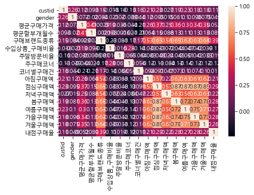

```python
sns.heatmap(dataPP.corr(), annot=True)
```

```python
# 학습용 데이터 확정

dataPT = dataPP.copy()
dataPD = dataPT.drop(['주말방문비율', '저녁구매액', '평균할부개월수','수입상품_구매비율','주구매코너'], axis=1)

dfy = dataPD['gender']
dfX = dataPD.drop('gender', axis=1)
dfX.tail(2)
```

|  | custid | 평균구매가격 | 구매브랜드종류 | 코너별구매건 | 아침구매액 | 점심구매액 | 봄구매액 | 여름구매액 | 가을구매액 | 겨울구매액 | 내점구매율 |
| --- | --- | --- | --- | --- | --- | --- | --- | --- | --- | --- | --- |
| 4998 | 49732 | 314259 | 23 | 2219 | 1.477015e+07 | 3.928233e+07 | 8484982.398 | 2.388365e+07 | 1.445590e+07 | 1.319886e+07 | 2.449 |
| 4999 | 49954 | 183065 | 10 | 2219 | 5.491941e+05 | 2.562906e+06 | 1098388.235 | 1.830647e+05 | 7.322588e+05 | 1.098388e+06 | 1.308 |

```python
dfX.shape
```

```
(5000, 11)
```

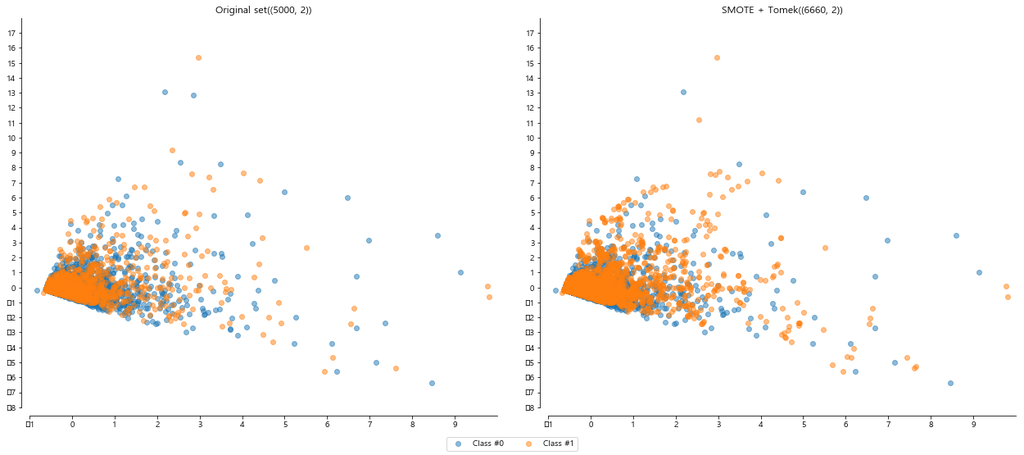

```
(5000, 11) (6660, 11) (4995, 11) (1665, 11)
```

```python
from imblearn.combine import *

# PCA로 feature 2개만 선택하여 Scatter로 시각화해 봄..
pca = PCA(n_components=2)
X_org = pca.fit_transform(dfX)
y_org = np.array(dfy)
X_resampled, y_resampled = SMOTETomek(random_state=0).fit_sample(dfX, dfy)
X_pca = pca.transform(X_resampled)

scaler = StandardScaler()
X_org_scaled = scaler.fit_transform(X_org)
X_pca_scaled = scaler.transform(X_pca)

title1 = 'Original set('+ str(X_org_scaled.shape) +')'
title2 = 'SMOTE + Tomek('+ str(X_pca_scaled.shape) +')'
xlim = [-1, 10]
ylim = [-8, 18]
xticks = range(-1, 10)
yticks = range(-8, 18)

# Scatter 그래프 그리기
drawSMOTETomek(X_org_scaled, y_org, X_pca_scaled, y_resampled, title1, title2, xlim, ylim, xticks, yticks)

X_train, X_test, y_train, y_test = train_test_split(X_resampled, y_resampled, test_size=0.25, random_state=0)
print(dfX.shape, X_resampled.shape, X_train.shape, X_test.shape)
```

- SMOTETomek 비대칭 데이터 OverSampling 처리
  - Scatter 그래프로 시각화하여 비교하기 위해 PCA와 StandardScaler를 사용함.
  - 실제 학습용으로는 SMOTETomek로 샘플링한 X_resampled, y_resampled를 사용함.

```python
# scoring="roc_auc|f1" => 0.496
temp_param1 = bestModel('SVC', 5, 'GRID', X_train, y_train, 'minmax', True, False, 'f1', -1, 10, 5)
best_param1 = {key.split("__")[1]:value for key, value in temp_param1.items() if key != 'polynomialfeatures__degree'}
svm1 = SVC(**best_param1)
score_svm1 = svm1.fit(X_train, y_train).score(X_test, y_test)
print("score_svm1 ::: {}".format(score_svm1))
print("-----------------------------------")
y_svm1 = svm1.predict(X_test)
print(classification_report(y_test, y_svm1))
```

```
Fitting 5 folds for each of 48 candidates, totalling 240 fits
```

```
[Parallel(n_jobs=-1)]: Using backend LokyBackend with 4 concurrent workers.
[Parallel(n_jobs=-1)]: Done  10 tasks      | elapsed:   19.2s
[Parallel(n_jobs=-1)]: Done  64 tasks      | elapsed:  1.4min
[Parallel(n_jobs=-1)]: Done 154 tasks      | elapsed:  5.1min
[Parallel(n_jobs=-1)]: Done 240 out of 240 | elapsed: 10.3min finished
```

```
score_svm1 ::: 0.4978978978978979
-----------------------------------
              precision    recall  f1-score   support

           0       0.00      0.00      0.00       836
           1       0.50      1.00      0.66       829

   micro avg       0.50      0.50      0.50      1665
   macro avg       0.25      0.50      0.33      1665
weighted avg       0.25      0.50      0.33      1665
```

```python
# scoring="roc_auc|f1" => 0.755
# categories_indices = [X_train.columns.get_loc(col) for col in ['주구매코너']]
best_param1 = bestGBDTNextModel('LGBM', False, 5, 'RANDOM', X_train, y_train, X_test, y_test, 15, 'roc_auc', 0, 3, -1)
lgbm1 = LGBMClassifier(**best_param1)
score_lgbm1 = lgbm1.fit(X_train, y_train).score(X_test, y_test)
print("score_lgbm1 ::: {}".format(score_lgbm1))
print("-----------------------------------")
y_lgbm1 = lgbm1.predict(X_test)
print(classification_report(y_test, y_lgbm1))

# 최고=0.755 Score LGBM best_estimator
#  LGBMClassifier(boosting_type='gbdt', class_weight=None, colsample_bytree=1.0,
#         importance_type='split', lambda_l1=0.01, lambda_l2=0,
#         learning_rate=0.01, max_depth=50, metric='auc',
#         min_child_samples=20, min_child_weight=0.001, min_data_in_leaf=20,
#         min_split_gain=0.0, n_estimators=300, n_jobs=-1,
#         num_boost_round=4000, num_leaves=150, objective='binary',
#         random_state=0, reg_alpha=0.1, reg_lambda=0.0, silent=True,
#         subsample=1.0, subsample_for_bin=200000, subsample_freq=0)
```

```
Fitting 5 folds for each of 15 candidates, totalling 75 fits
```

```
[Parallel(n_jobs=-1)]: Using backend LokyBackend with 4 concurrent workers.
[Parallel(n_jobs=-1)]: Done  24 tasks      | elapsed:  5.2min
[Parallel(n_jobs=-1)]: Done  75 out of  75 | elapsed: 19.7min finished
```

```
LGBM grid_.best_score 0.849
LGBM grid_.best_score 0.868
LGBM best_estimator LGBMClassifier(boosting_type='gbdt', class_weight=None, colsample_bytree=1.0,
        importance_type='split', lambda_l1=0.01, lambda_l2=0.01,
        learning_rate=0.05, max_depth=100, metric='auc',
        min_child_samples=20, min_child_weight=0.001, min_data_in_leaf=20,
        min_split_gain=0.0, n_estimators=300, n_jobs=-1,
        num_boost_round=5000, num_leaves=200, objective='binary',
        random_state=0, reg_alpha=0.01, reg_lambda=0.1, silent=True,
        subsample=1, subsample_for_bin=200000, subsample_freq=0)
score_lgbm1 ::: 0.7855855855855856
-----------------------------------
              precision    recall  f1-score   support

           0       0.78      0.81      0.79       836
           1       0.80      0.76      0.78       829

   micro avg       0.79      0.79      0.79      1665
   macro avg       0.79      0.79      0.79      1665
weighted avg       0.79      0.79      0.79      1665
```

## 전개(Deployment)

```python
# 1. 예측용 데이터를 로드한다.
news = pd.read_csv('./data/test.csv', encoding='CP949')
newsP = news.copy()
newsP.head(2)
```

|  | custid | 총구매액 | 구매건수 | 평균구매가격 | 평균할부개월수 | 구매브랜드종류 | 내점일수 | 수입상품_구매비율 | 주말방문비율 | 가을_구매건수 | 겨울_구매건수 | 봄_구매건수 | 여름_구매건수 | 아침_구매건수 | 저녁_구매건수 | 점심_구매건수 | 주구매코너 |
| --- | --- | --- | --- | --- | --- | --- | --- | --- | --- | --- | --- | --- | --- | --- | --- | --- | --- |
| 0 | 100001 | 3439000 | 25 | 137560 | 2.2 | 19 | 16 | 12.0 | 31.2 | 5.0 | 4.0 | 7.0 | 9.0 | 13.0 | 1.0 | 11.0 | 장신구 |
| 1 | 100002 | 2073090 | 39 | 53156 | 1.3 | 18 | 29 | 0.0 | 20.7 | 13.0 | 8.0 | 10.0 | 8.0 | 4.0 | 10.0 | 25.0 | 유아동복 |

```python
have_missing_value(newsP)
```

```
custid          0
총구매액            0
구매건수            0
평균구매가격          0
평균할부개월수         0
구매브랜드종류         0
내점일수            0
수입상품_구매비율       0
주말방문비율          0
가을_구매건수       948
겨울_구매건수       911
봄_구매건수        681
여름_구매건수       991
아침_구매건수      1392
저녁_구매건수      1025
점심_구매건수       139
주구매코너           0
dtype: int64
```

```python
# 2. 예측용 데이터 결측치 처리 및 비분석 컬럼 삭제
newsP.fillna(value=0, inplace=True)

for col in newsP[cate].dtypes.index:
    print("newsP['"+ col +"'].astype('category').cat.categories")
    newsP[col].astype('category').cat.categories

newsP[cate] = newsP[cate].apply(lambda x: x.astype('category').cat.codes)
newsP.tail(3)
```

```
newsP['주구매코너'].astype('category').cat.categories
```

|  | custid | 총구매액 | 구매건수 | 평균구매가격 | 평균할부개월수 | 구매브랜드종류 | 내점일수 | 수입상품_구매비율 | 주말방문비율 | 가을_구매건수 | 겨울_구매건수 | 봄_구매건수 | 여름_구매건수 | 아침_구매건수 | 저녁_구매건수 | 점심_구매건수 | 주구매코너 |
| --- | --- | --- | --- | --- | --- | --- | --- | --- | --- | --- | --- | --- | --- | --- | --- | --- | --- |
| 4997 | 104998 | 960923 | 12 | 80077 | 1.8 | 7 | 7 | 0.0 | 42.9 | 4.0 | 1.0 | 6.0 | 1.0 | 0.0 | 0.0 | 12.0 | 14 |
| 4998 | 104999 | 786600 | 14 | 56186 | 1.7 | 12 | 9 | 14.3 | 55.6 | 0.0 | 7.0 | 4.0 | 3.0 | 2.0 | 4.0 | 8.0 | 24 |
| 4999 | 105000 | 2568073 | 76 | 33790 | 1.6 | 23 | 35 | 10.5 | 22.9 | 23.0 | 20.0 | 9.0 | 24.0 | 11.0 | 4.0 | 61.0 | 14 |

```python
# 3. 예측용 데이터에 '코너별구매건' 컬럼 추가
nd0 = newsP.groupby(['주구매코너'])['구매건수'].agg(sum)
nd0 = nd0.to_frame().reset_index()
nd0.columns = ['주구매코너', '코너별구매건']
# nd0.head(3)
newsP_ = pd.merge(newsP, nd0, on='주구매코너')
# newsP_.head(2)

# 4. 예측용 데이터의 건수 Feature들을 최소단위 정보인 구매건당 구매액로 변경한다.
createFeatures(newsP_)
newsPP = dropFeatures(newsP_) # 파생 Feature -> 유도 Feature들 삭제
# newsPP[(newsPP['주구매코너']==2)].head(3)

# 5. 머신러닝 예측용 데이터 변환 완료
X_pred = newsPP.drop(['주말방문비율', '저녁구매액', '평균할부개월수','수입상품_구매비율','주구매코너'], axis=1)
X_pred.tail(2)
```

|  | custid | 평균구매가격 | 구매브랜드종류 | 코너별구매건 | 아침구매액 | 점심구매액 | 봄구매액 | 여름구매액 | 가을구매액 | 겨울구매액 | 내점구매율 |
| --- | --- | --- | --- | --- | --- | --- | --- | --- | --- | --- | --- |
| 4998 | 104474 | 107060 | 15 | 319 | 107060.0 | 1284720.0 | 428240.0 | 321180.0 | 749420.0 | 107060.0 | 1.5 |
| 4999 | 104752 | 63625 | 8 | 319 | 0.0 | 381750.0 | 254500.0 | 254500.0 | 0.0 | 0.0 | 2.0 |

### Best Model training

```python
best_model1 = LGBMClassifier(boosting_type='gbdt', class_weight=None, colsample_bytree=1.0,
         importance_type='split', lambda_l1=0.01, lambda_l2=0,
         learning_rate=0.01, max_depth=50, metric='auc',
         min_child_samples=20, min_child_weight=0.001, min_data_in_leaf=20,
         min_split_gain=0.0, n_estimators=300, n_jobs=-1,
         num_boost_round=4000, num_leaves=150, objective='binary',
         random_state=0, reg_alpha=0.1, reg_lambda=0.0, silent=True,
         subsample=1.0, subsample_for_bin=200000, subsample_freq=0)

score_best1 = best_model1.fit(X_train, y_train).score(X_test, y_test)
y_best1 = best_model1.predict(X_test)

print("best_model1 -----------------------------{}".format(score_best1))
print(classification_report(y_test, y_best1))
```

```
best_model1 -----------------------------0.7867867867867868
              precision    recall  f1-score   support

           0       0.77      0.81      0.79       836
           1       0.80      0.76      0.78       829

   micro avg       0.79      0.79      0.79      1665
   macro avg       0.79      0.79      0.79      1665
weighted avg       0.79      0.79      0.79      1665
```

```python
best_model2 = XGBClassifier(base_score=0.5, booster='gbtree', colsample_bylevel=1,
        colsample_bytree=1, gamma=0, learning_rate=0.07, max_delta_step=0,
        max_depth=7, min_child_weight=1, missing=None, n_estimators=700,
        n_jobs=1, nthread=3, objective='binary:logistic', random_state=0,
        reg_alpha=0.01, reg_lambda=0.1, scale_pos_weight=1, seed=None,
        silent=True, subsample=1)

score_best2 = best_model2.fit(X_train, y_train).score(X_test, y_test)
y_best2 = best_model2.predict(X_test)

print("best_model2 -----------------------------{}".format(score_best2))
print(classification_report(y_test, y_best2))
```

[output not shown]

#### SMOTETomek로 재샘플링한 데이터가 narray 형식이므로 예측용 데이터도 narray로 변환하여 예측한다.

```python
#new_D = X_pred.copy()
#new_T = X_pred.loc[:,'평균구매가격':'내점구매율']
#X_new = new_T.as_matrix(['평균구매가격','구매브랜드종류','코너별구매건','아침구매액','점심구매액','봄구매액','여름구매액','가을구매액','겨울구매액','내점구매율'])
# X_new
new_D.head()
```

[output not shown]

```python
new_D = X_pred.copy()
new_T = dataPT.drop(['주말방문비율', '저녁구매액', '평균할부개월수','수입상품_구매비율','주구매코너'], axis=1)
new_T = new_T.drop('gender', axis=1)
new_T.tail(2)
```

|  | custid | 평균구매가격 | 구매브랜드종류 | 코너별구매건 | 아침구매액 | 점심구매액 | 봄구매액 | 여름구매액 | 가을구매액 | 겨울구매액 | 내점구매율 |
| --- | --- | --- | --- | --- | --- | --- | --- | --- | --- | --- | --- |
| 4998 | 49732 | 314259 | 23 | 2219 | 1.477015e+07 | 3.928233e+07 | 8484982.398 | 2.388365e+07 | 1.445590e+07 | 1.319886e+07 | 2.449 |
| 4999 | 49954 | 183065 | 10 | 2219 | 5.491941e+05 | 2.562906e+06 | 1098388.235 | 1.830647e+05 | 7.322588e+05 | 1.098388e+06 | 1.308 |

```python
display(dfX.shape, new_T.shape)
```

```
(5000, 11)
```

```
(5000, 11)
```

```python
new_D['pred']       = best_model1.predict(new_T)
new_D['pred_prob']  = best_model1.predict_proba(new_T)[:,1]
```

```python
news.sort_values(by=['custid']).tail(3)
```

|  | custid | 총구매액 | 구매건수 | 평균구매가격 | 평균할부개월수 | 구매브랜드종류 | 내점일수 | 수입상품_구매비율 | 주말방문비율 | 가을_구매건수 | 겨울_구매건수 | 봄_구매건수 | 여름_구매건수 | 아침_구매건수 | 저녁_구매건수 | 점심_구매건수 | 주구매코너 |
| --- | --- | --- | --- | --- | --- | --- | --- | --- | --- | --- | --- | --- | --- | --- | --- | --- | --- |
| 4997 | 104998 | 960923 | 12 | 80077 | 1.8 | 7 | 7 | 0.0 | 42.9 | 4.0 | 1.0 | 6.0 | 1.0 | NaN | NaN | 12.0 | 일반식품 |
| 4998 | 104999 | 786600 | 14 | 56186 | 1.7 | 12 | 9 | 14.3 | 55.6 | NaN | 7.0 | 4.0 | 3.0 | 2.0 | 4.0 | 8.0 | 화장품 |
| 4999 | 105000 | 2568073 | 76 | 33790 | 1.6 | 23 | 35 | 10.5 | 22.9 | 23.0 | 20.0 | 9.0 | 24.0 | 11.0 | 4.0 | 61.0 | 일반식품 |

```python
new_D.sort_values(by=['custid']).tail(3)
```

|  | custid | 평균구매가격 | 구매브랜드종류 | 코너별구매건 | 아침구매액 | 점심구매액 | 봄구매액 | 여름구매액 | 가을구매액 | 겨울구매액 | 내점구매율 | pred | pred_prob |
| --- | --- | --- | --- | --- | --- | --- | --- | --- | --- | --- | --- | --- | --- |
| 2423 | 104998 | 80077 | 7 | 74942 | 0.000 | 960923.000 | 480461.500 | 80076.917 | 320307.667 | 80076.917 | 1.714 | 1 | 0.998683 |
| 3743 | 104999 | 56186 | 12 | 26123 | 112371.429 | 449485.714 | 224742.857 | 168557.143 | 0.000 | 393300.000 | 1.556 | 1 | 0.999046 |
| 2424 | 105000 | 33790 | 23 | 74942 | 371694.776 | 2061216.487 | 304113.908 | 810970.421 | 777179.987 | 675808.684 | 2.171 | 0 | 0.008723 |

```python
dfN = new_D[['custid', 'pred', 'pred_prob']]
#dfN
targets = pd.merge(news, dfN, on='custid')
targets.tail(5)
```

|  | custid | 총구매액 | 구매건수 | 평균구매가격 | 평균할부개월수 | 구매브랜드종류 | 내점일수 | 수입상품_구매비율 | 주말방문비율 | 가을_구매건수 | 겨울_구매건수 | 봄_구매건수 | 여름_구매건수 | 아침_구매건수 | 저녁_구매건수 | 점심_구매건수 | 주구매코너 | pred | pred_prob |
| --- | --- | --- | --- | --- | --- | --- | --- | --- | --- | --- | --- | --- | --- | --- | --- | --- | --- | --- | --- |
| 4995 | 104996 | 670690 | 5 | 134138 | 1.4 | 5 | 4 | 0.0 | 75.0 | 1.0 | 2.0 | 2.0 | NaN | 1.0 | 1.0 | 3.0 | 일반식품 | 0 | 0.000954 |
| 4996 | 104997 | 628700 | 13 | 48362 | 1.8 | 10 | 7 | 7.7 | 42.9 | NaN | 5.0 | 1.0 | 7.0 | NaN | 3.0 | 10.0 | 조리욕실 | 0 | 0.000773 |
| 4997 | 104998 | 960923 | 12 | 80077 | 1.8 | 7 | 7 | 0.0 | 42.9 | 4.0 | 1.0 | 6.0 | 1.0 | NaN | NaN | 12.0 | 일반식품 | 1 | 0.998683 |
| 4998 | 104999 | 786600 | 14 | 56186 | 1.7 | 12 | 9 | 14.3 | 55.6 | NaN | 7.0 | 4.0 | 3.0 | 2.0 | 4.0 | 8.0 | 화장품 | 1 | 0.999046 |
| 4999 | 105000 | 2568073 | 76 | 33790 | 1.6 | 23 | 35 | 10.5 | 22.9 | 23.0 | 20.0 | 9.0 | 24.0 | 11.0 | 4.0 | 61.0 | 일반식품 | 0 | 0.008723 |

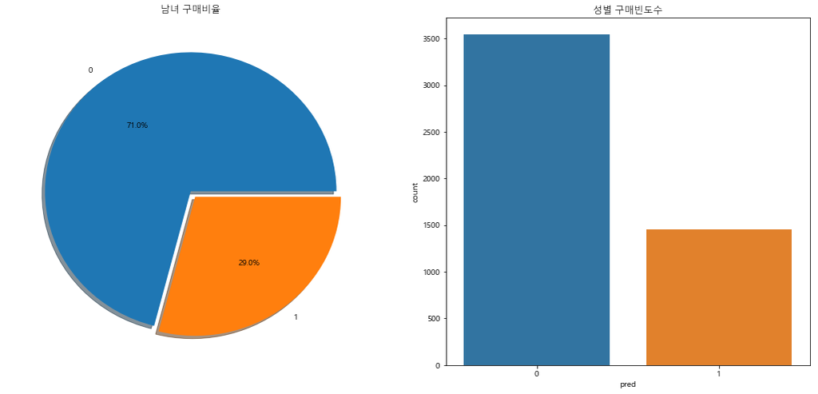

```python
f, ax = plt.subplots(1,2,figsize=(18,8))

# 구매에 대한 남녀 빈도 체크
gender_freq = targets.pred.value_counts()
gender_freq.plot.pie(explode=[0,0.05], autopct='%1.1f%%', ax=ax[0], shadow=True)
ax[0].set_title('남녀 구매비율', fontproperties=font_prop)
ax[0].set_ylabel('')

# 구매에 대한 남녀 빈도 체크 -> 히스토그램
sns.countplot('pred', data=targets, ax=ax[1])
ax[1].set_title('성별 구매빈도수', fontproperties=font_prop)
plt.show()
```

```python
# 예측한 Data를 파일로(화일명: 이름-학번-sub.csv) 저장하여 제출한다.
targets.sort_values(by="custid", ascending=False).to_csv("KimDongUg-U2018031.csv", index=False)
pd.read_csv("KimDongUg-U2018031.csv").count()
```

```
custid       5000
총구매액         5000
구매건수         5000
평균구매가격       5000
평균할부개월수      5000
구매브랜드종류      5000
내점일수         5000
수입상품_구매비율    5000
주말방문비율       5000
가을_구매건수      4052
겨울_구매건수      4089
봄_구매건수       4319
여름_구매건수      4009
아침_구매건수      3608
저녁_구매건수      3975
점심_구매건수      4861
주구매코너        5000
pred         5000
pred_prob    5000
dtype: int64
```

```python
result_data = pd.read_csv('KimDongUg-U2018031.csv')
result_data
```

|  | custid | 총구매액 | 구매건수 | 평균구매가격 | 평균할부개월수 | 구매브랜드종류 | 내점일수 | 수입상품_구매비율 | 주말방문비율 | 가을_구매건수 | 겨울_구매건수 | 봄_구매건수 | 여름_구매건수 | 아침_구매건수 | 저녁_구매건수 | 점심_구매건수 | 주구매코너 | pred | pred_prob |
| --- | --- | --- | --- | --- | --- | --- | --- | --- | --- | --- | --- | --- | --- | --- | --- | --- | --- | --- | --- |
| 0 | 105000 | 2568073 | 76 | 33790 | 1.6 | 23 | 35 | 10.5 | 22.9 | 23.0 | 20.0 | 9.0 | 24.0 | 11.0 | 4.0 | 61.0 | 일반식품 | 0 | 8.723126e-03 |
| 1 | 104999 | 786600 | 14 | 56186 | 1.7 | 12 | 9 | 14.3 | 55.6 | NaN | 7.0 | 4.0 | 3.0 | 2.0 | 4.0 | 8.0 | 화장품 | 1 | 9.990465e-01 |
| 2 | 104998 | 960923 | 12 | 80077 | 1.8 | 7 | 7 | 0.0 | 42.9 | 4.0 | 1.0 | 6.0 | 1.0 | NaN | NaN | 12.0 | 일반식품 | 1 | 9.986834e-01 |
| 3 | 104997 | 628700 | 13 | 48362 | 1.8 | 10 | 7 | 7.7 | 42.9 | NaN | 5.0 | 1.0 | 7.0 | NaN | 3.0 | 10.0 | 조리욕실 | 0 | 7.730388e-04 |
| 4 | 104996 | 670690 | 5 | 134138 | 1.4 | 5 | 4 | 0.0 | 75.0 | 1.0 | 2.0 | 2.0 | NaN | 1.0 | 1.0 | 3.0 | 일반식품 | 0 | 9.539671e-04 |
| 5 | 104995 | 1745665 | 21 | 83127 | 1.7 | 16 | 7 | 9.5 | 71.4 | 2.0 | NaN | 2.0 | 17.0 | 2.0 | 1.0 | 18.0 | 영캐주얼 | 0 | 2.276386e-05 |
| 6 | 104994 | 3679946 | 43 | 85580 | 2.3 | 27 | 24 | 2.3 | 29.2 | 8.0 | 13.0 | 6.0 | 16.0 | 8.0 | 8.0 | 27.0 | 유니캐주얼 | 0 | 6.405788e-04 |
| 7 | 104993 | 8446156 | 82 | 103002 | 2.1 | 44 | 48 | 1.2 | 18.8 | 21.0 | 24.0 | 17.0 | 20.0 | 12.0 | 24.0 | 46.0 | 유아동복 | 0 | 1.118890e-03 |
| 8 | 104992 | 3051050 | 40 | 76276 | 2.1 | 23 | 23 | 12.5 | 17.4 | 5.0 | 14.0 | 18.0 | 3.0 | 2.0 | 11.0 | 27.0 | 화장품 | 1 | 9.987635e-01 |
| 9 | 104991 | 826384 | 8 | 103298 | 3.4 | 4 | 6 | 0.0 | 16.7 | 1.0 | 1.0 | 2.0 | 4.0 | NaN | 1.0 | 7.0 | 화장품 | 1 | 9.985923e-01 |
| 10 | 104990 | 124000 | 2 | 62000 | 1.0 | 2 | 2 | 50.0 | 50.0 | NaN | NaN | NaN | 2.0 | NaN | NaN | 2.0 | 화장품 | 0 | 4.288537e-04 |
| 11 | 104989 | 134270 | 4 | 33568 | 1.5 | 3 | 3 | 25.0 | 33.3 | NaN | 4.0 | NaN | NaN | 1.0 | NaN | 3.0 | 일반식품 | 0 | 1.036180e-03 |
| 12 | 104988 | 237005 | 10 | 23700 | 1.6 | 7 | 5 | 20.0 | 0.0 | NaN | 2.0 | 1.0 | 7.0 | 4.0 | NaN | 6.0 | 도자기크리스탈 | 0 | 1.208191e-03 |
| 13 | 104987 | 1555600 | 10 | 155560 | 3.2 | 8 | 8 | 30.0 | 75.0 | 1.0 | 4.0 | 3.0 | 2.0 | 3.0 | 3.0 | 4.0 | 정장셔츠 | 1 | 9.993125e-01 |
| 14 | 104986 | 259000 | 6 | 43167 | 1.7 | 5 | 5 | 16.7 | 0.0 | NaN | 1.0 | 4.0 | 1.0 | 1.0 | 2.0 | 3.0 | 화장품 | 1 | 9.996091e-01 |
| 15 | 104985 | 2149483 | 26 | 82672 | 2.1 | 18 | 21 | 15.4 | 57.1 | 7.0 | 5.0 | 3.0 | 11.0 | NaN | 6.0 | 20.0 | 화장품 | 1 | 9.991943e-01 |
| 16 | 104984 | 3398860 | 29 | 117202 | 1.1 | 22 | 10 | 34.5 | 20.0 | NaN | 19.0 | 5.0 | 5.0 | NaN | 20.0 | 9.0 | 화장품 | 0 | 9.253481e-04 |
| 17 | 104983 | 2148800 | 41 | 52410 | 1.2 | 27 | 21 | 19.5 | 19.0 | 12.0 | 4.0 | 13.0 | 12.0 | 6.0 | 4.0 | 31.0 | 화장품 | 1 | 9.997435e-01 |
| 18 | 104982 | 113000 | 1 | 113000 | 3.0 | 1 | 1 | 100.0 | 0.0 | NaN | NaN | 1.0 | NaN | NaN | NaN | 1.0 | 화장품 | 0 | 1.502137e-03 |
| 19 | 104981 | 23884758 | 62 | 385238 | 2.2 | 45 | 24 | 16.1 | 37.5 | 16.0 | 9.0 | 15.0 | 22.0 | 12.0 | 13.0 | 37.0 | 스포츠 | 0 | 5.176314e-02 |
| 20 | 104980 | 142000 | 2 | 71000 | 1.0 | 2 | 2 | 0.0 | 50.0 | 1.0 | NaN | NaN | 1.0 | 1.0 | NaN | 1.0 | 피혁A | 0 | 6.864359e-04 |
| 21 | 104979 | 11661500 | 12 | 971792 | 2.2 | 6 | 9 | 83.3 | 44.4 | 1.0 | 4.0 | NaN | 7.0 | 3.0 | 1.0 | 8.0 | 수입명품 | 0 | 7.866314e-04 |
| 22 | 104978 | 2680811 | 48 | 55850 | 1.6 | 28 | 26 | 8.3 | 7.7 | 20.0 | 5.0 | 9.0 | 14.0 | 33.0 | NaN | 15.0 | 일반식품 | 1 | 9.992140e-01 |
| 23 | 104977 | 1851162 | 31 | 59715 | 1.3 | 18 | 18 | 16.1 | 22.2 | 5.0 | 12.0 | 4.0 | 10.0 | 7.0 | 4.0 | 20.0 | 일반식품 | 0 | 4.381519e-04 |
| 24 | 104976 | 458200 | 2 | 229100 | 3.0 | 2 | 1 | 0.0 | 0.0 | NaN | NaN | NaN | 2.0 | NaN | NaN | 2.0 | 디자이너부띠끄 | 0 | 8.994936e-05 |
| 25 | 104975 | 274500 | 3 | 91500 | 1.7 | 3 | 3 | 33.3 | 66.7 | 2.0 | NaN | NaN | 1.0 | NaN | 3.0 | NaN | 유아동복 | 0 | 8.108858e-04 |
| 26 | 104974 | 1055000 | 6 | 175833 | 2.7 | 6 | 4 | 50.0 | 75.0 | 2.0 | 2.0 | NaN | 2.0 | NaN | 4.0 | 2.0 | 화장품 | 0 | 1.293161e-03 |
| 27 | 104973 | 2693735 | 32 | 84179 | 1.8 | 9 | 20 | 18.8 | 45.0 | 11.0 | 9.0 | 5.0 | 7.0 | 1.0 | 9.0 | 22.0 | 일반식품 | 0 | 8.361004e-04 |
| 28 | 104972 | 3240051 | 135 | 24000 | 1.3 | 35 | 45 | 8.1 | 24.4 | 48.0 | 50.0 | 17.0 | 20.0 | 8.0 | 51.0 | 76.0 | 일반식품 | 0 | 6.233774e-04 |
| 29 | 104971 | 11345750 | 53 | 214071 | 1.6 | 35 | 18 | 30.2 | 44.4 | 22.0 | 14.0 | 15.0 | 2.0 | 1.0 | 8.0 | 44.0 | 정장셔츠 | 1 | 9.993815e-01 |
| ... | ... | ... | ... | ... | ... | ... | ... | ... | ... | ... | ... | ... | ... | ... | ... | ... | ... | ... | ... |
| 4970 | 100030 | 4331510 | 35 | 123757 | 1.6 | 26 | 16 | 28.6 | 50.0 | 5.0 | 11.0 | 16.0 | 3.0 | NaN | 10.0 | 25.0 | 화장품 | 0 | 3.897042e-04 |
| 4971 | 100029 | 6399559 | 147 | 43534 | 1.7 | 47 | 55 | 0.0 | 32.7 | 46.0 | 34.0 | 35.0 | 32.0 | 28.0 | 25.0 | 94.0 | 스포츠 | 1 | 9.902003e-01 |
| 4972 | 100028 | 380640 | 11 | 34604 | 1.4 | 11 | 8 | 9.1 | 50.0 | 5.0 | 1.0 | NaN | 5.0 | NaN | 5.0 | 6.0 | 화장품 | 1 | 9.994101e-01 |
| 4973 | 100027 | 1227970 | 20 | 61398 | 2.2 | 14 | 11 | 45.0 | 18.2 | 7.0 | NaN | 2.0 | 11.0 | NaN | 4.0 | 16.0 | 수입명품 | 1 | 9.977391e-01 |
| 4974 | 100026 | 3525382 | 29 | 121565 | 2.3 | 16 | 19 | 3.4 | 63.2 | 3.0 | 7.0 | 11.0 | 8.0 | 4.0 | 2.0 | 23.0 | 일반식품 | 0 | 1.759833e-04 |
| 4975 | 100025 | 14726596 | 168 | 87658 | 2.0 | 84 | 53 | 13.1 | 45.3 | 47.0 | 25.0 | 44.0 | 52.0 | 93.0 | 13.0 | 62.0 | 유아동복 | 0 | 1.359293e-06 |
| 4976 | 100024 | 10525869 | 98 | 107407 | 2.4 | 42 | 34 | 16.3 | 32.4 | 26.0 | 31.0 | 16.0 | 25.0 | 22.0 | 19.0 | 57.0 | 유니캐주얼 | 0 | 6.395950e-04 |
| 4977 | 100023 | 191000 | 3 | 63667 | 1.7 | 3 | 1 | 66.7 | 0.0 | NaN | NaN | NaN | 3.0 | NaN | NaN | 3.0 | 화장품 | 0 | 1.626053e-04 |
| 4978 | 100022 | 1981400 | 25 | 79256 | 1.5 | 17 | 14 | 8.0 | 64.3 | 6.0 | 11.0 | 3.0 | 5.0 | 1.0 | 1.0 | 23.0 | 영캐주얼 | 0 | 1.342538e-01 |
| 4979 | 100021 | 229000 | 3 | 76333 | 3.0 | 3 | 1 | 33.3 | 0.0 | NaN | 3.0 | NaN | NaN | NaN | NaN | 3.0 | 유아동복 | 0 | 2.821296e-06 |
| 4980 | 100020 | 15107942 | 47 | 321446 | 2.3 | 32 | 23 | 29.8 | 34.8 | 21.0 | 4.0 | 5.0 | 17.0 | 6.0 | 17.0 | 24.0 | 일반식품 | 0 | 8.107848e-04 |
| 4981 | 100019 | 414000 | 4 | 103500 | 1.0 | 3 | 2 | 100.0 | 0.0 | NaN | 4.0 | NaN | NaN | NaN | NaN | 4.0 | 화장품 | 1 | 9.990435e-01 |
| 4982 | 100018 | 2225600 | 16 | 139100 | 2.2 | 9 | 11 | 50.0 | 27.3 | 4.0 | NaN | 8.0 | 4.0 | 8.0 | NaN | 8.0 | 수입명품 | 0 | 2.124956e-02 |
| 4983 | 100017 | 6032500 | 75 | 80433 | 2.1 | 33 | 29 | 26.7 | 51.7 | 14.0 | 23.0 | 21.0 | 17.0 | 7.0 | 9.0 | 59.0 | 화장품 | 0 | 1.953664e-01 |
| 4984 | 100016 | 6722660 | 32 | 210083 | 3.0 | 18 | 15 | 21.9 | 26.7 | 9.0 | 4.0 | 15.0 | 4.0 | 5.0 | 7.0 | 20.0 | 디자이너부띠끄 | 1 | 9.992244e-01 |
| 4985 | 100015 | 3705689 | 15 | 247046 | 1.9 | 11 | 6 | 33.3 | 50.0 | 8.0 | 1.0 | NaN | 6.0 | 2.0 | 7.0 | 6.0 | 섬유 | 0 | 1.821754e-02 |
| 4986 | 100014 | 682472 | 14 | 48748 | 1.0 | 7 | 10 | 7.1 | 30.0 | 4.0 | 4.0 | 4.0 | 2.0 | NaN | 12.0 | 2.0 | 일반식품 | 1 | 9.991379e-01 |
| 4987 | 100013 | 487300 | 7 | 69614 | 2.4 | 5 | 4 | 0.0 | 75.0 | 4.0 | NaN | NaN | 3.0 | 3.0 | NaN | 4.0 | 정장셔츠 | 0 | 2.742406e-02 |
| 4988 | 100012 | 2264840 | 30 | 75495 | 1.5 | 27 | 17 | 3.3 | 29.4 | 2.0 | 3.0 | 9.0 | 16.0 | 15.0 | 1.0 | 14.0 | 유아동복 | 0 | 7.974063e-06 |
| 4989 | 100011 | 5643401 | 82 | 68822 | 2.2 | 32 | 40 | 20.7 | 37.5 | 19.0 | 20.0 | 9.0 | 34.0 | 9.0 | 9.0 | 64.0 | 일반식품 | 0 | 6.574808e-04 |
| 4990 | 100010 | 2318515 | 26 | 89174 | 1.3 | 10 | 16 | 19.2 | 43.8 | 9.0 | 3.0 | 10.0 | 4.0 | 3.0 | NaN | 23.0 | 일반식품 | 0 | 7.249511e-04 |
| 4991 | 100009 | 3889520 | 44 | 88398 | 1.6 | 30 | 21 | 13.6 | 38.1 | 5.0 | 17.0 | 5.0 | 17.0 | 8.0 | 6.0 | 30.0 | 스포츠 | 0 | 3.632151e-01 |
| 4992 | 100008 | 558610 | 9 | 62068 | 1.2 | 8 | 9 | 11.1 | 33.3 | 4.0 | 4.0 | 1.0 | NaN | NaN | 4.0 | 5.0 | 기타바이어 | 1 | 9.967140e-01 |
| 4993 | 100007 | 565400 | 8 | 70675 | 1.8 | 5 | 4 | 12.5 | 50.0 | 1.0 | NaN | NaN | 7.0 | 1.0 | NaN | 7.0 | 니트단품 | 1 | 9.988585e-01 |
| 4994 | 100006 | 1071000 | 17 | 63000 | 1.4 | 11 | 12 | 11.8 | 25.0 | 3.0 | 12.0 | 2.0 | NaN | NaN | 11.0 | 6.0 | 섬유 | 0 | 3.807664e-02 |
| 4995 | 100005 | 1297640 | 26 | 49909 | 2.3 | 13 | 9 | 11.5 | 22.2 | 18.0 | NaN | 5.0 | 3.0 | NaN | NaN | 26.0 | 스포츠 | 1 | 9.988926e-01 |
| 4996 | 100004 | 6696522 | 46 | 145577 | 1.7 | 31 | 22 | 37.0 | 50.0 | 5.0 | 15.0 | 9.0 | 17.0 | NaN | 4.0 | 42.0 | 수입명품 | 1 | 9.985515e-01 |
| 4997 | 100003 | 1303800 | 22 | 59264 | 1.8 | 14 | 12 | 0.0 | 41.7 | 6.0 | 7.0 | 3.0 | 6.0 | 3.0 | 1.0 | 18.0 | 유아동복 | 0 | 1.211372e-04 |
| 4998 | 100002 | 2073090 | 39 | 53156 | 1.3 | 18 | 29 | 0.0 | 20.7 | 13.0 | 8.0 | 10.0 | 8.0 | 4.0 | 10.0 | 25.0 | 유아동복 | 0 | 1.595278e-05 |
| 4999 | 100001 | 3439000 | 25 | 137560 | 2.2 | 19 | 16 | 12.0 | 31.2 | 5.0 | 4.0 | 7.0 | 9.0 | 13.0 | 1.0 | 11.0 | 장신구 | 0 | 8.175769e-07 |

5000 rows × 19 columns